# Clase 3: Series de tiempo

Jorge de la Vega

13/10/2021

# Series de tiempo: Modelos de descomposición (continuación )

Como hemos comentado, a partir de los métodos de suavizamiento se crean pronósticos combinando información dela última observación de los datos con la estimación de los componentes proyectados de la serie, tal como el componente estacional o el de tendencia.

- Ya vimos que los **promedios móviles** sirven para separar la señal del ruido de una serie.
- Vimos que los métodos de descomposición consideran a las series de tiempo como una combinación de cuatro componentes (o tres):
  - Tendencia
  - Estacionalidad
  - Ciclo
  - Error

y que la descomposición se puede hacer de manera **lineal** o **multiplicativa**.

Ahora consideraremos una amplicación de modelos que hace una descomposición ligeramente diferente, introduciendo el concepto de **nivel o base** (que en realidad es parte de la tendencia):

- En un modelo aditivo, el nivel es como la constante $a$ en un modelo de regresión de la forma $a + b\times t$ y representa el nivel al inicio del periodo. La tendencia se asocia con la pendiente $b$ e indica la tasa de crecimiento por unidad de tiempo.
- En un modelo multiplicativo, el nivel se asocia con la constante $a$ y la tendencia con la constante $b$ en un modelo de la forma $at^b$.

## Método de Holt-Winters

A diferencia de otros métodos, el método de Holt-Winters se basa en el suavizamiento exponencial e incorpora tanto factores de tendencia como de estacionalidad.

Como los factores estacionales cambian constantemente en muchas de las series de tiempo, los método generales como el de Holt-Winters, que permite actualizar los coeficientes estimados durante cada periodo, serán mejores que los métodos que mantienen constantes esos valores. La elección del método a aplicar dependerá del análisis preeliminar que hagan de las serie de tiempo que estén analizando.

El modelo de Holt-Winters considera tres características de la serie de tiempo:

- $L_t$ = nivel (o base)
- $T_t$ = tendencia
- $S_t$ = componente estacional

Se tienen 4 ecuaciones (versión multiplicativa) y tres parámetros (se muestra el modelo multiplicativo primero y el aditivo en paréntesis):

1. M: $L_t = \alpha \frac{y_t}{S_{t-s}} +(1-\alpha)(L_{t-1}\cdot T_{t-1})$ A: ( $L_t = \alpha \frac{y_t}{S_{t-s}} +(1-\alpha)(L_{t-1} + T_{t-1})$ )
2. M: $T_t = \beta(\frac{L_t}{L_{t-1}}) + (1-\beta)T_{t-1}$ A: ( $T_t = \beta(L_t - L_{t-1}) + (1-\beta)T_{t-1}$ )
3. M: $S_t = \gamma(\frac{y_t}{L_t}) + (1-\gamma)S_{t-s}$ A: ( $S_t = \gamma(\frac{y_t}{L_t}) + (1-\gamma)S_{t-s}$ )

donde $s$ es la longitud de la estacionalidad

La ecuación 1 indica que el estimado del nuevo nivel es un promedio ponderado de la observaciòn actual (desestacionalizada) y el nivel del último periodo, actualizado por la última tendencia disponible.

La ecuación 2 indica que el nuevo estimador de la tendencia es un promedio ponderado de la razón del nivel actual al nivel del periodo anterior (esto da un nuevo estimador de tendencia) y la tendencia del último periodo.

La ecuación 3 indica que el nuevo factor estacional es un promedio ponderado del estimado del factor estacional basado en el periodo actual y el estimado previo.

Se puede definir el pronóstico $F_{t+k} = L_t\cdot T_t^kS_{t+k-s}$ (para el aditivo: $F_{t+k} = (L_t + k\times T_t)\cdot S_{t+k-s}$ ).

El método de Holt-Winters requiere definir condiciones de inicialización de los componentes $L_t$, $T_t$ y los índices estacionales $S_t$. Podemos seguir por ejemplo, este procedimiento:

- $S_t$: requiere los datos completos de todo un periodo estacional
- $L_t$: se calcula el valor para $s$ como un promedio de $s$ observaciones: $L_s = \frac{1}{s}(y_1 + \cdots + y_s)$.
- $T_t$: se calcula el valor para $s$: $T_s = \frac{1}{s}(\frac{y_{s+1} - y_1}{s} + \cdots + \frac{y_{2s} - y_s}{s})$.
- Los valores de $\alpha, \beta$ y $\gamma$ se eligen de tal forma que minimicen el error cuadrático medio (MSE) o alguna otra medida de error.

### Ejemplo

Aquí usaremos datos que corresponden a millas mensuales recorridas por líneas aéreas en los EEUU que están en el archivo `airlines HW.xls` para comparar los resultados en Excel y en R. Los datos de pasajeros muestran una tendencia y un factor estacional.

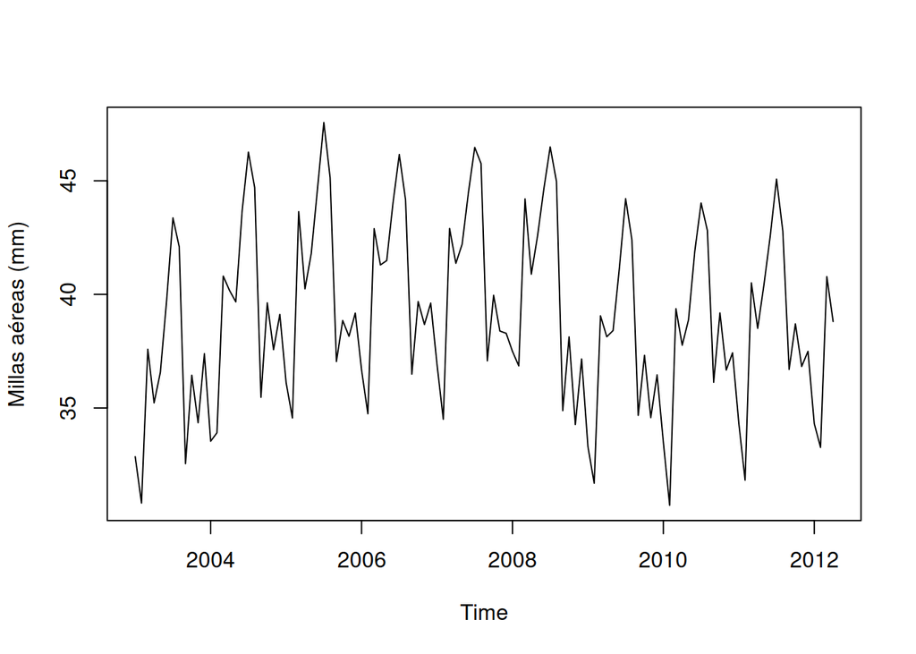

```r
ruta <- "/home/jvega/Dropbox/Academia/ITAM/2021-II/Modelos de Mercadotecnia/data/"
library(readxl)
y <- readxl::read_xls("../data/airlines HW.xls", sheet = "datos", range = "B1:B113")
y <- readxl::read_xls(paste0(ruta,"airlines HW.xls"), sheet = "datos", range = "B1:B113")
y <- ts(y, start=c(2003,01), freq=12)
plot(y)
```

En R, la función `HoltWinters` permite definir un ajuste considerando un modelo aditivo o multiplicativo en la parte estacional.

```r
m1 <- HoltWinters(y,seasonal = "multiplicative")
names(m1) # son los componentes que se crean
```

```
[1] "fitted"       "x"            "alpha"        "beta"         "gamma"
[6] "coefficients" "seasonal"     "SSE"          "call"
```

```r
head(m1$fitted) # podemos ver los componentes estimados
```

```
         xhat    level     trend    season
[1,] 31.95241 36.30862 0.2698892 0.8735295
[2,] 33.28643 37.59562 0.3180596 0.8779530
[3,] 40.58899 38.31127 0.3368894 1.0502179
[4,] 40.16945 38.76357 0.3423551 1.0271959
[5,] 39.74502 39.10777 0.3424425 1.0074729
[6,] 43.83549 39.40903 0.3404921 1.1027929
```

```r
c(m1$alpha, m1$beta, m1$gamma) # podemos ver los parámtros estimados
```

```
     alpha       beta      gamma
0.56056083 0.04735994 0.77465352
```

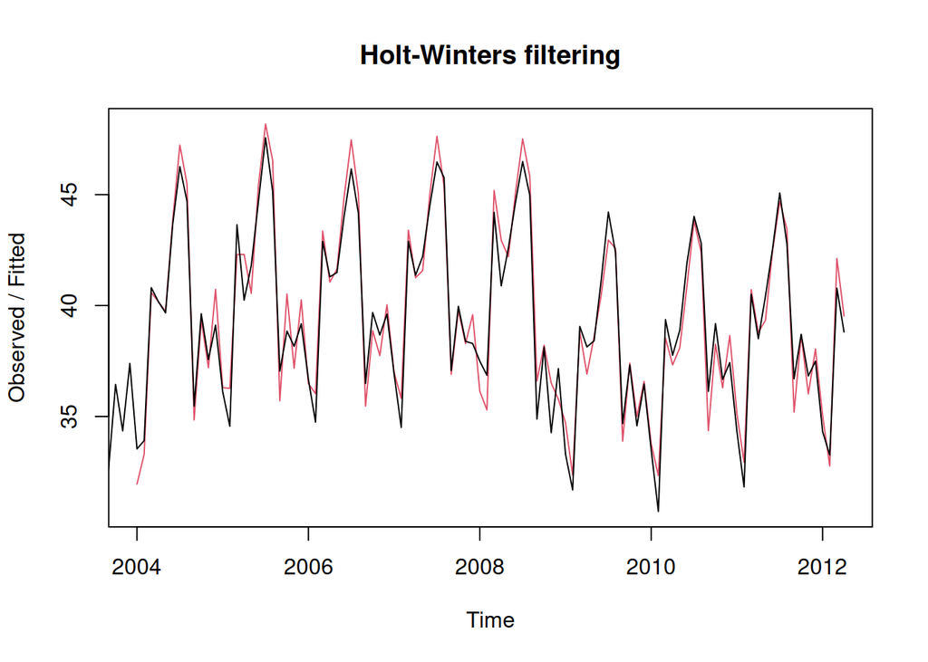

```r
plot(m1) # muestra el ajuste y los datos originales
```

Una gráfica de los componentes estimados de la serie:

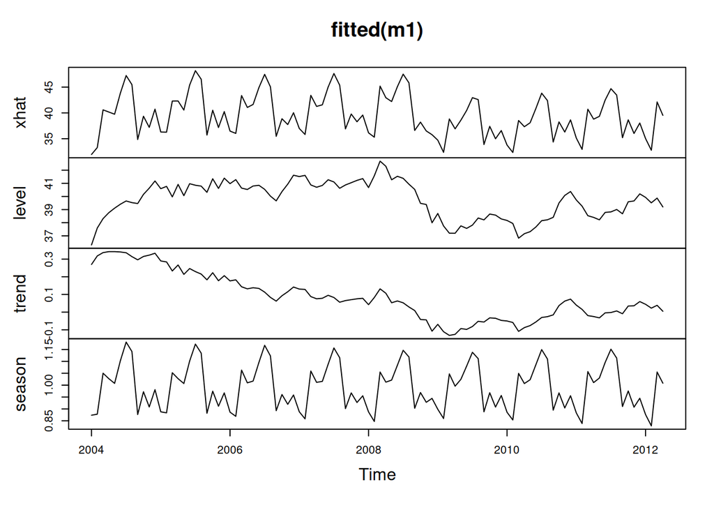

```r
plot(fitted(m1))
```

```r
pron <- predict(m1,n.ahead = 20,prediction.interval = T)
pron
```

```
              fit       upr       lwr
May 2012 40.32775  42.01103  38.64447
Jun 2012 42.51034  44.55273  40.46795
Jul 2012 44.75370  47.15975  42.34764
Aug 2012 42.92368  45.55188  40.29548
Sep 2012 35.75570  38.35319  33.15821
Oct 2012 37.78363  40.77152  34.79574
Nov 2012 35.38562  38.49876  32.27248
Dec 2012 36.38289  39.84180  32.92397
Jan 2013 33.65559  37.16554  30.14564
Feb 2013 32.20661  35.85678  28.55643
Mar 2013 40.33725  45.07876  35.59574
Apr 2013 38.70738 157.65198 -80.23721
May 2013 40.15074 120.70214 -40.40065
Jun 2013 42.32368 131.10475 -46.45738
Jul 2013 44.55712 142.10084 -52.98660
Aug 2013 42.73507 140.20848 -54.73834
Sep 2013 35.59853 120.06919 -48.87213
Oct 2013 37.61749 130.33040 -55.09543
Nov 2013 35.22996 125.29982 -54.83989
Dec 2013 36.22279 132.16156 -59.71598
```

Otra opción es usar el paquete forecast para obtener una mejor gráfica de los pronósticos e intervalos de confianza, aunque es importante notar que los resultados pueden diferir debido a que los programas usan diferentes condiciones de inicialización.

```r
library(forecast)
m2 <- hw(y,h = 10)
names(m2) # componentes del modelo estimado Tiene diferentes conceptos del modelo previo.
```

```
 [1] "model"     "mean"      "level"     "x"         "upper"     "lower"
 [7] "fitted"    "method"    "series"    "residuals"
```

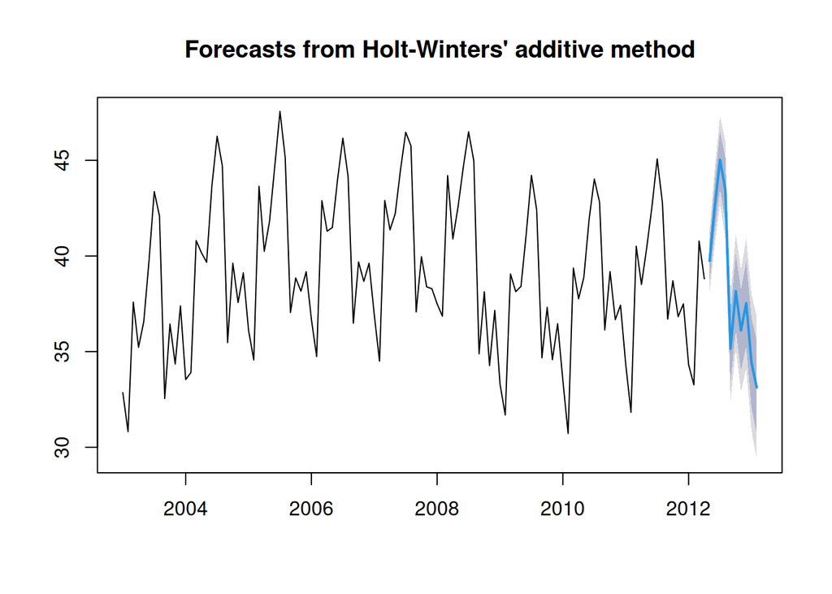

```r
plot(m2)
```

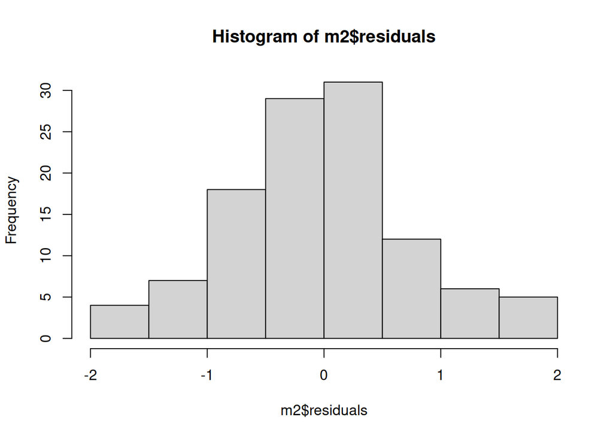

```r
hist(m2$residuals) # histograma de los residuales.
```

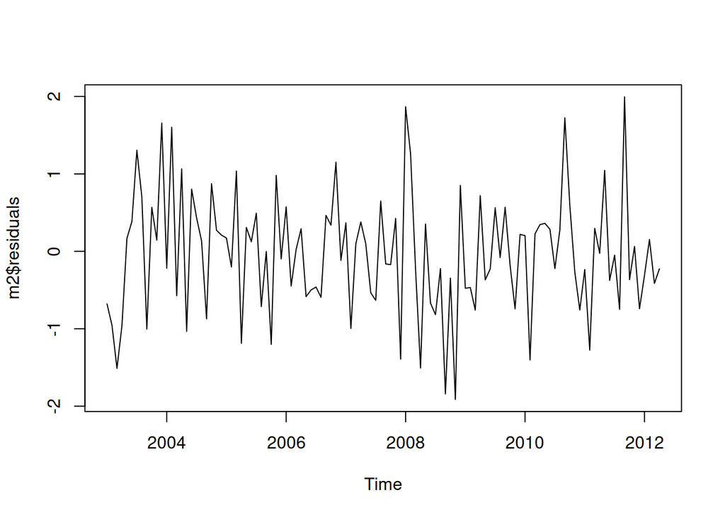

```r
plot(m2$residuals)
```

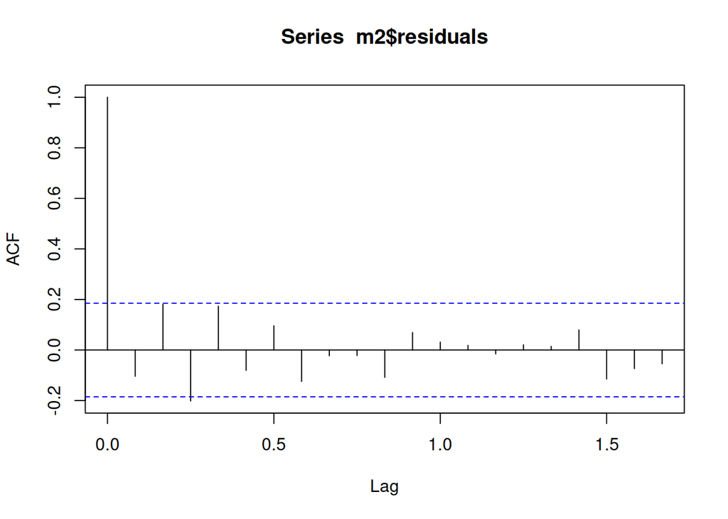

```r
acf(m2$residuals)
```

Podemos comparar los pronósticos a través de las medidas de desempeño que mencionamos la clase anterior (y que están e las notas).

```r
accuracy(m2) # toma los datos del modelo como el conjunto completo y calcula los errores del propio modelo.
```

```
                      ME      RMSE       MAE        MPE     MAPE      MASE
Training set -0.03407861 0.7745875 0.6102698 -0.1207529 1.606009 0.4638166
                   ACF1
Training set -0.1038063
```

```r
accuracy(m2, x=pron[1:10])  # tomo los pronósticos generados con el primer modelo como si fueran los datos observados
```

```
                      ME      RMSE       MAE        MPE     MAPE      MASE
Training set -0.03407861 0.7745875 0.6102698 -0.1207529 1.606009 0.1964681
Test set     -0.36670157 0.6706668 0.6025299 -1.0316176 1.654447 0.1939763
                   ACF1
Training set -0.1038063
Test set             NA
```

```r
accuracy(m2, x=1:10)  # tomo los pronósticos generados con el primer modelo como si fueran los datos observados
```

```
                       ME       RMSE        MAE           MPE        MAPE
Training set  -0.03407861  0.7745875  0.6102698    -0.1207529    1.606009
Test set     -33.03525141 33.6427035 33.0352514 -1073.0335299 1073.033530
                   MASE       ACF1
Training set  0.1964681 -0.1038063
Test set     10.6352510         NA
```

```r
m3 <- naive(y,h = 10)
accuracy(m3)
```

```
                     ME     RMSE      MAE        MPE    MAPE     MASE
Training set 0.05361923 3.953526 3.106203 -0.3838685 8.06861 2.360774
                   ACF1
Training set -0.2630681
```

Si se provee el argumento `x` a la función, entonces divide los datos en dos partes, y con una parte estima el modelo (training) y con la otra (test) calcula el error.

# Modelos ARIMA

Los modelos más comunes de series de tiempo son conocidos como **modelos ARIMA**, que significa: Autoregresive, Integrated, Moving Average. Estos modelos describen *series estacionarias*.

Estos modelos fueron propuestos en los 70’s por George Box y Gwilym Jenkins y son esenciales para entender otros modelos mucho más complicados que se utilizan en la práctica, como los modelos ARCH y GARCH, los modelos de espacio de estados, los modelos de cadenas de Markov ocultos, los modelos dinámicos lineales, etc.

## Metodología de Box-Jenkins

La metodología se divide en 4 fases: Lo dividiremos en 4 fases:

I. **Identificación:** preparación de los datos y selección del modelo. Utiliza los datos históricos para identificar un modelo apropiado.

2. **Estimación:** estima los parámetros de modelos potenciales y selecciona el mejor modelo.
3. **Diagnósticos:** se utilizan varios diagnósticos para evaluar si el modelo es adecuado.
4. **Aplicación:** se usa el modelo para hacer pronósticos y otros estudios.

Las primeras dos fases pueden repetirse si los diagnósticos indican que los modelos no son adecuados.

### Ejemplo. Datos de Kleenex

Para conocer el margen de mercado que tiene Kimberly-Clark con la marca kleenex, se le han pedido su producción semanal, que reporta para las 120 semanas anteriores a ésta y en unidades de 10,000 paquetes. Se requiere un modelo para analizar su comportamiento y hacer un pronóstico para saber si no está inundando el mercado.

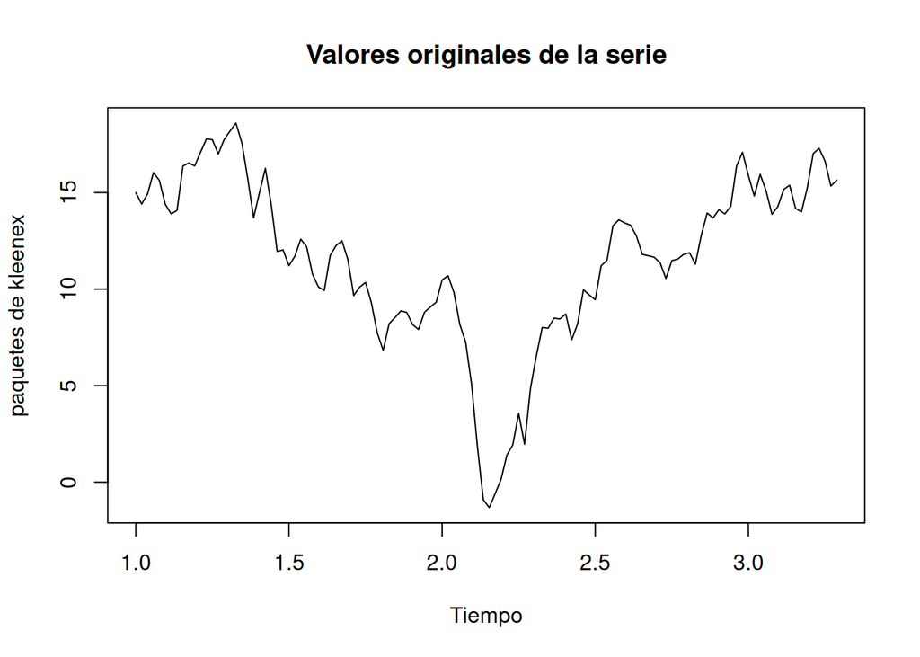

```r
kleenex <- read.table(file = "../data/kleenex.txt") # lee los datos
kleenex <- ts(kleenex, start = 1, freq = 52) # convierte a una serie con frecuencia semanal.
plot(kleenex, main = "Valores originales de la serie", xlab = "Tiempo", ylab = "paquetes de kleenex")
```

Lo primero a investigar es si la serie es estacionaria. Si no lo es, se pueden tomar diferencias de las observaciones

```r
dkleenex <- diff(kleenex, differences = 1)
head(dkleenex)
```

```
Time Series:
Start = c(1, 2)
End = c(1, 7)
Frequency = 52
          V1
[1,] -0.5936
[2,]  0.5319
[3,]  1.0991
[4,] -0.4054
[5,] -1.2345
[6,] -0.5016
```

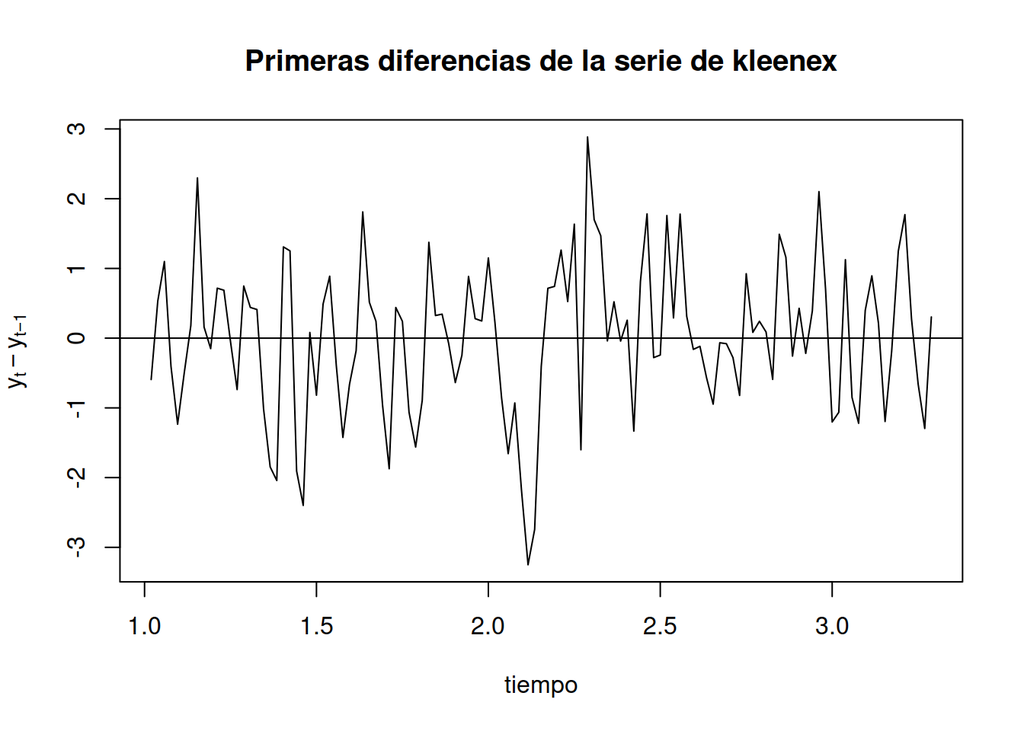

```r
plot(dkleenex, main = "Primeras diferencias de la serie de kleenex",
     xlab = "tiempo",
     ylab = expression(y[t]-y[t-1]))
abline(h=0)
```

A veces es necesario tomar varias diferencias para volver la serie estacionaria.

```r
d2kleenex <- diff(kleenex,differences = 2)  # genera las segundas diferencias
head(d2kleenex)
```

```
Time Series:
Start = c(1, 3)
End = c(1, 8)
Frequency = 52
          V1
[1,]  1.1255
[2,]  0.5672
[3,] -1.5045
[4,] -0.8291
[5,]  0.7329
[6,]  0.6822
```

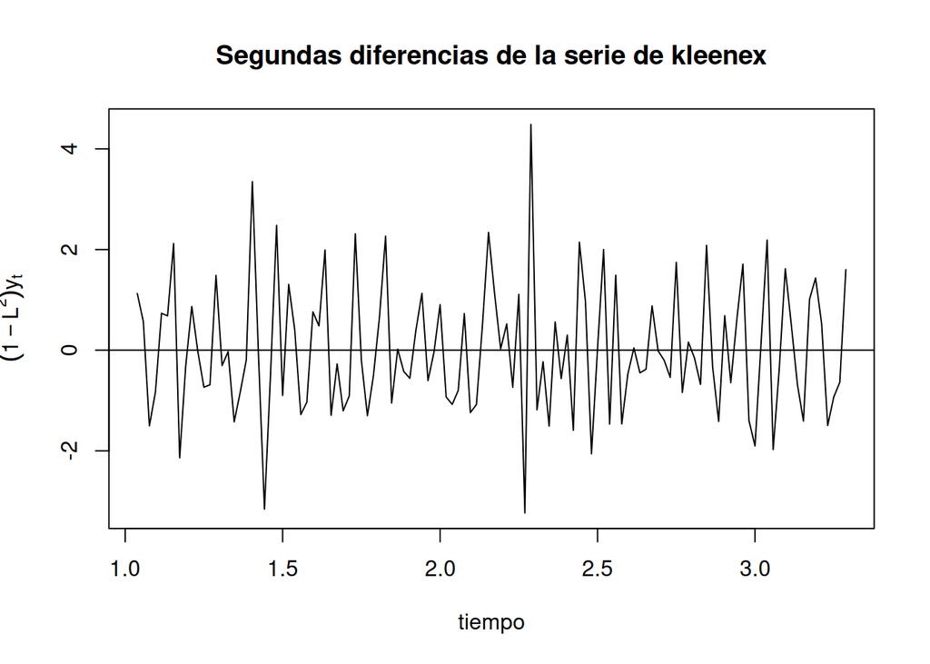

```r
plot(d2kleenex, main = "Segundas diferencias de la serie de kleenex",
     xlab = "tiempo",
     ylab = expression((1-L^2)*y[t]))
abline(h=0)
```

Una forma más formal de verificar que una serie es estacionaria es calcular las **funciones de autocorrelación** y **autocorrelación parcial**. Del mismo modo se pueden considerar las pruebas de Dickey-Fueller o Phillis-Perron.

El coeficiente de autocorrelación de orden $k$ describe cuál es la relación que hay entre valores de la serie de tiempo que están separados por $k$ periodos

$$r_k = \frac{\sum_{t=k+1}^n(y_t-\bar{y})(y_{t-k}-\bar{y})}{\sum_{t=1}^n(y_t-\bar{y})^2} = \frac{\hat{\gamma}_k}{\hat{\gamma}_0}$$

donde $\hat{\gamma}_k$ es la covarianza estimada entre $y_t$ y $y_{t-k}$, y $\hat{\gamma}_0$ es la varianza estimada de la serie.

$r_1$ indica cómo se relacionan valores sucesivos de $y_t$ entre sí; $r_2$ indica cómo se relacionan valores $y_t$ que están separados por dos periodos, etc.

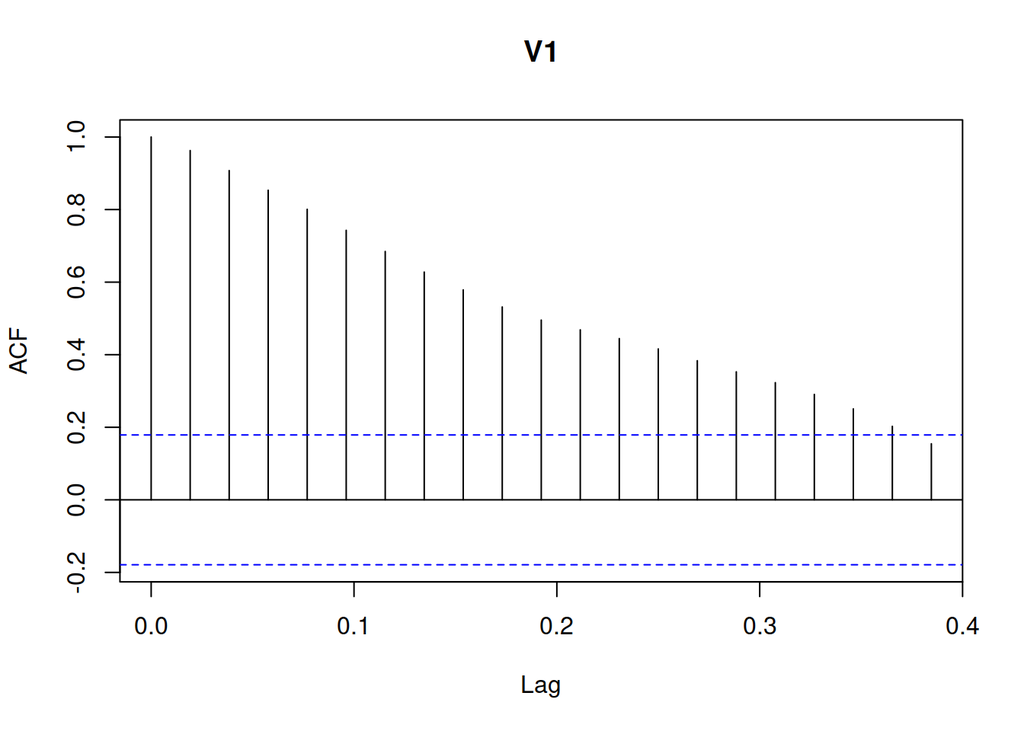

```r
acf(kleenex) # tipica forma de una serie no estacionaria
```

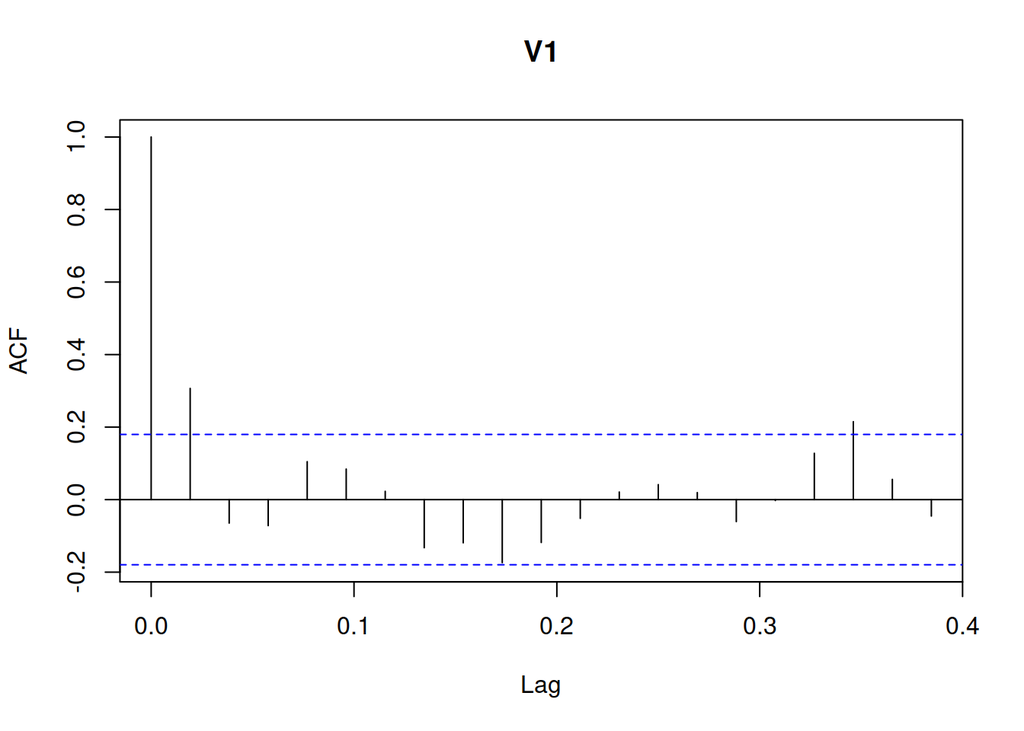

```r
acf(dkleenex) # acf de la primera diferencia mejora
```

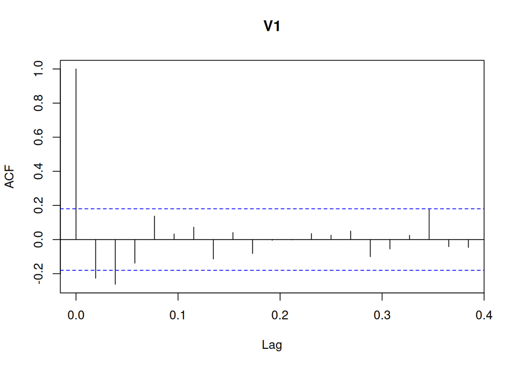

```r
acf(d2kleenex) # no se ve mucho cambio con la anterior.
```

Las *autocorrelaciones parciales* se usan para medir el grado de asociación entre $y_t$ y $y_{t-k}$, cuando se ha eliminado el efecto de los rezagos intermedios $1,2,3,\ldots,k-1$.

El coeficiente de autocorrelación parcial de orden $k$ se denota por $\alpha_k$ y se calcula haciendo la regresión de $y_t$ contra los rezagos $y_{t-1},\ldots,y_{t-k}$:

$$y_t = \alpha_0 + \alpha_1 y_{t-1} + \cdots + \alpha_k y_{t-k}$$

La función de autocorrelación parcial es la grafica de $\alpha_k$ vs. $k$.

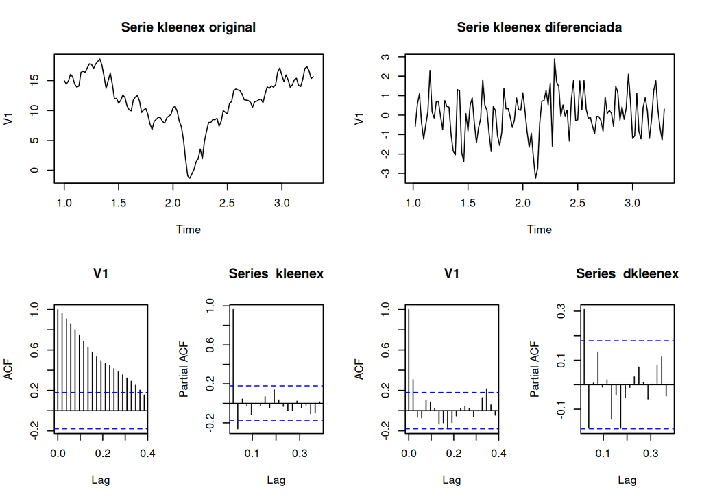

```r
# Para la serie de Kimberly, por ejemplo, podemos ver los dos casos, con la serie original y la serie diferenciada.
layout(matrix(c(1,1,2,2,3,4,5,6),nrow=2,byrow=T))
        plot(kleenex, main = "Serie kleenex original")
        plot(dkleenex, main = "Serie kleenex diferenciada")
        acf(kleenex)
        pacf(kleenex)
        acf(dkleenex)
        pacf(dkleenex)
```

### Ejemplo: ruido blanco

Un modelo en el que cada observación se compone de dos partes, un nivel constante $c$ y un componente de error $\epsilon_t$ que es independiente de cualquier periodo,

$$y_t = c + \epsilon_t$$

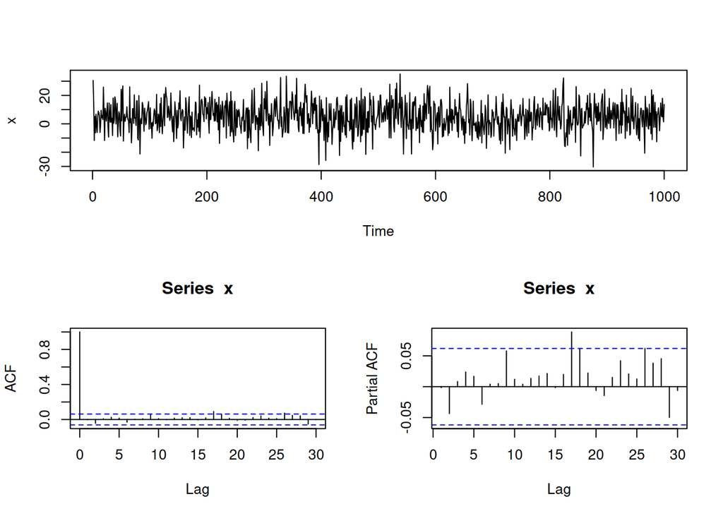

```r
x <- rnorm(1000,mean=5, sd=10)
layout(matrix(c(1,1,2,3),nrow=2,byrow=T))
plot.ts(x)
acf(x)
pacf(x)
```

Por ejemplo, para los residuales del modelo de Holt-Winters

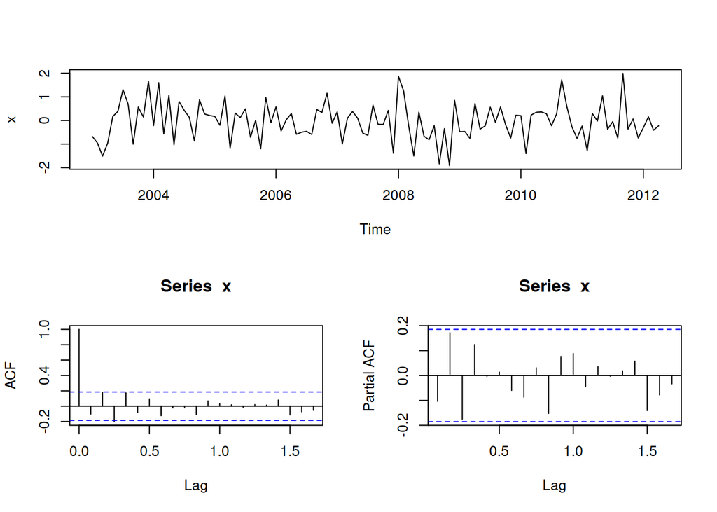

```r
x <- m2$residuals
layout(matrix(c(1,1,2,3),nrow=2,byrow=T))
plot.ts(x)
acf(x)
pacf(x)
```

## Modelos AR y MA

Un modelo autorregresivo de orden $p$, que se denota por $AR(p)$ es un modelo de la forma:

$$y_t = \phi_0 + \phi_1 y_{t-1} + \phi_2 y_{t-2} + \cdots + \phi_p y_{t-p} + \epsilon_t$$

done $\epsilon_t \sim N(0,\sigma^2_{\epsilon})$, y los errores son independientes.

En este modelo los predictores de la observación $y_t$ son sus propios rezagos en el tiempo.

Los modelos $AR$ pueden ser estacionarios o no estacionarios, dependiendo de las restricciones que se impongan sobre los pesos del modelo.

Un modelo de promedios móviles de orden $q$ es un modelo de la forma:

$$y_t = \theta_0 + \theta_1 \epsilon_{t-1} + \theta_2 \epsilon_{t-2} + \cdots + \theta_q \epsilon_{t-q} + \epsilon_t$$
donde $\{\epsilon_t\}$ es una serie de ruido blanco.

A este proceso se le llama promedio móvil porque es una especie de promedio móvil en la serie $\{\epsilon_t\}$, con pesos dados por los coeficientes $\theta\_1,\theta\_2,\ldots, \theta\_q$.

### Ejemplo de estimación de un modelo ARIMA

Dada la falta de tiempo para ver en detalle las características de las funciones acf y pacf para identificar modelos, consideraremos un enfoque de *fuerza bruta* para ajustar los modelos y utilizar el criterio de Akaike para seleccionar el modelo.

Podemos considerar ajustar todos los modelos para las combinaciones de valores $p,d,q$ en los conjuntos $p \in \{0,1,2,3,4\}$, $d\in \{0,1,2\}$, y $q \in \{0,1,2,3,4\}$.

Sin embargo, este método no funcionará para series con un fuerte componente estacional. En caso de contar con componente estacional se recomienda primero eliminar la estacionalidad con los métodos vistos previamente.

También se pueden extender los modelos a modelos SARIMA($p,d,q$)($P,D,Q$), que contemplan un componente estacional, pero esos modelos son más complicados y no se verán aquí.

```r
# Ajuste por fuerza bruta de los datos de kleenex
AIC <- array(NA, dim=c(4,2,4), dimnames = list(paste("p=",0:3), paste("d=",0:1), paste("q=",0:3)))
for(p in 1:4)
  for(q in 1:4)
    for(d in 1:2) AIC[p,d,q] <- arima(kleenex, order = c(p-1,d-1,q-1))$aic
    AIC[,1,]
```

```
         q= 0     q= 1     q= 2     q= 3
p= 0 698.9005 568.3708 475.5712 437.5709
p= 1 369.6550 356.3556 358.1165 358.6551
p= 2 358.3822 358.2153 357.4390 359.2192
p= 3 357.5850 359.5559 359.2680 360.9870
```

```r
    AIC[,2,]
```

```
         q= 0     q= 1     q= 2     q= 3
p= 0 362.2711 349.9821 351.9519 351.8757
p= 1 352.5789 351.9658 351.3134 352.6993
p= 2 350.7612 352.7601 353.5758 353.2524
p= 3 352.7582 352.4818 349.9126 350.9945
```

El modelo que mejor ajusta estos datos está dado por el caso con el *menor* AIC, que corresponde a los valores $p=3$, $d=1$ y $q=2$, sugiriendo un ajuste de la forma ARIMA($3,1,2$). No es muy distinto al valor que se tiene para el modelo con $p=0,d=1,q=1$ que también puede ser un buen candidato.

Entonces los modelos que se pueden proponer para valorar en los diagnósticos son los modelos ARIMA($3,1,2$) y ARIMA($0,1,1$). Usualmente, si se tienen dos o más modelos que no difieren mucho en la calidad del ajuste, siempre se escoge el más sencillo. Este es el *principio de parsimonia*.

```r
mod1 <- arima(kleenex, order = c(3,1,2)); mod1
```

```
Call:
arima(x = kleenex, order = c(3, 1, 2))

Coefficients:
         ar1      ar2     ar3      ma1     ma2
      1.5308  -1.3686  0.3847  -1.2517  0.9587
s.e.  0.0876   0.1047  0.0894   0.0463  0.0711

sigma^2 estimated as 0.9869:  log likelihood = -168.96,  aic = 349.91
```

```r
mod2 <- arima(kleenex, order = c(0,1,1)); mod2
```

```
Call:
arima(x = kleenex, order = c(0, 1, 1))

Coefficients:
         ma1
      0.3518
s.e.  0.0800

sigma^2 estimated as 1.071:  log likelihood = -172.99,  aic = 349.98
```

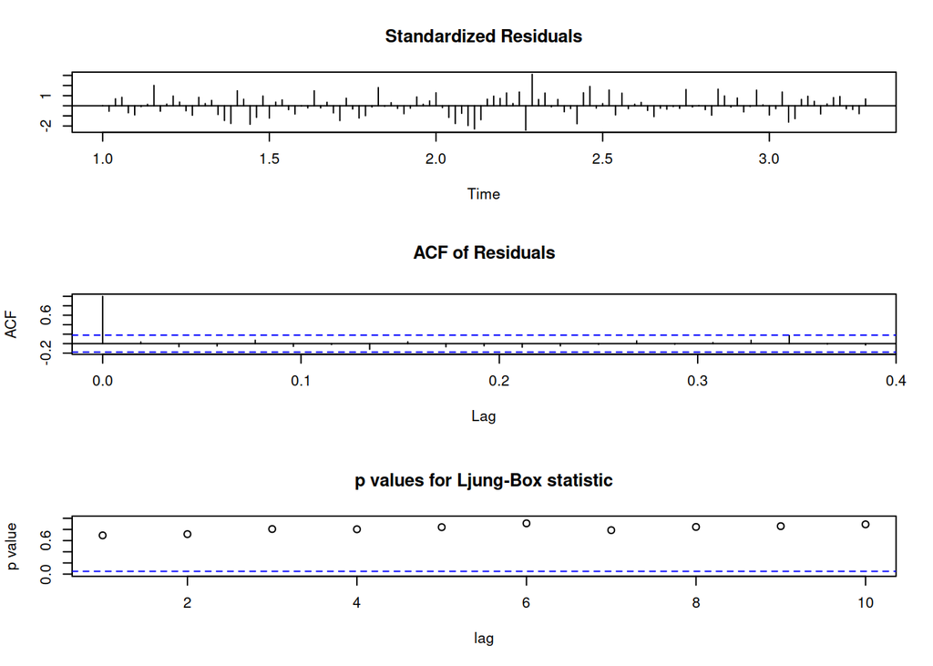

```r
tsdiag(mod1)
```

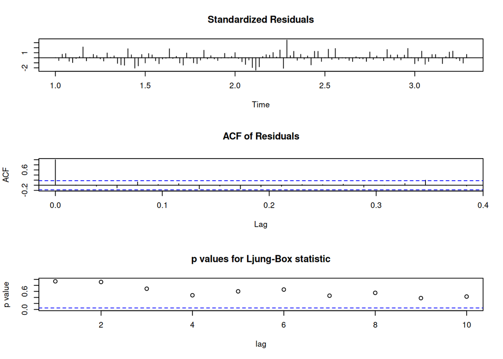

```r
tsdiag(mod2)
```

Los pronósticos se hacen de la siguiente manera:

```r
pron2 <- predict(mod2,n.ahead = 12)  # Haz una predicción de 12 periodos.
pron2
```

```
$pred
Time Series:
Start = c(3, 17)
End = c(3, 28)
Frequency = 52
 [1] 15.88725 15.88725 15.88725 15.88725 15.88725 15.88725 15.88725 15.88725
 [9] 15.88725 15.88725 15.88725 15.88725

$se
Time Series:
Start = c(3, 17)
End = c(3, 28)
Frequency = 52
 [1] 1.034805 1.739997 2.232568 2.634602 2.982935 3.294643 3.579307 3.842943
 [9] 4.089618 4.322239 4.542964 4.753450
```

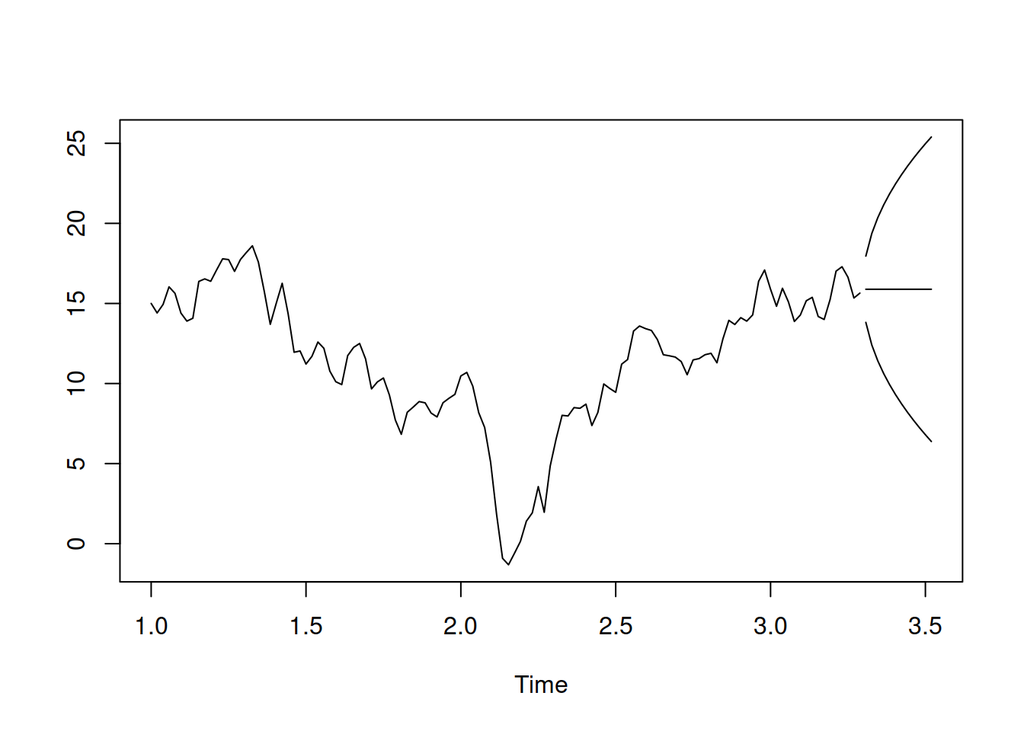

```r
ts.plot(kleenex, pron2$pred, pron2$pred +2*pron2$se,pron2$pred -2*pron2$se)
```

## Pruebas de estacionariedad: Dickey-Fuller

Es importante probar formalmente que una serie es estacionaria, particularmente en econometría. Las pruebas de estacionariedad se conocen como *prueba de raíz unitaria*. La prueba de Dickey-Fuller es una prueba de este tipo.

La prueba consiste en estimar la regresión:

$$\Delta y_t = \phi y_{t-1} +\beta_1\Delta y_{t-1} + \beta_2 \Delta y_{t-2} + \cdots + \beta_p \Delta y_{t-p} + u_t$$
donde $u_t$ es un componente de error que se supone tiene media 0.

Si la serie no es estacionaria, entonces se espera que $\hat{\phi}\approx 0$. Si la serie es estacionaria, entonces $\hat{\phi} <0$.

Como los errores de este modelo están correlacionados, los supuestos típicos de regresión lineal no se cumplen, por lo que hay que probar la hipótesis $H_0:\phi=0$ vs. $H_a:\phi<0$ utilizando una prueba diferente a la prueba de $t$ que se usa en regresión normal.

```r
library(tseries)
adf.test(kleenex) #no se rechaza la hipótesis nula, por lo que no es estacionaria
```

```
    Augmented Dickey-Fuller Test

data:  kleenex
Dickey-Fuller = -1.7786, Lag order = 4, p-value = 0.6685
alternative hypothesis: stationary
```

```r
adf.test(dkleenex, k = 1) # se rechaza H0, la serie es estacionaria
```

```
    Augmented Dickey-Fuller Test

data:  dkleenex
Dickey-Fuller = -7.5879, Lag order = 1, p-value = 0.01
alternative hypothesis: stationary
```

```r
adf.test(d2kleenex, k = 0) # la serie es estacionaria
```

```
    Augmented Dickey-Fuller Test

data:  d2kleenex
Dickey-Fuller = -13.442, Lag order = 0, p-value = 0.01
alternative hypothesis: stationary
```